# seqBio: A sequence alginment package

Laura Julià Melis

## 1. Introducción.

El paquete **seqBio** contiene dos objetos: las funciones `seq_alignment()` y `generateSeqsWithMultinomialModel()`. La primera función es útil para estudiar la significación del alineamiento de secuencias y para ello, reliza el cálculo de la probabilidad de que la puntuación del alineamiento ha sido obtenida por azar (aplicando la estrategia de *shuffling*). La función `generateSeqsWithMultinomialModel()` es una función auxiliar dentro de `seq_alignment()`, necesaria para generar un numero determinado de secuencias aleatorias.

## 2. Argumentos de seq_alignment().

La función `seq_alignment()` no tiene valores por defecto por lo que para ejecutarla, será **siempre** necesario dar valores a todos sus argumentos de entrada.

# 2. Comprobación de los inputs:

- `seq1:` Secuencia 1 en formato Fasta (objeto de tipo carácter).
- `seq2:` Secuencia 2 en formato Fasta (objeto de tipo carácter).
- `seq_type:` Tipo de secuencia: “protein” o “dna” (objeto de tipo carácter).
- `seq_align:` Tipo de alineamiento: “local” o “global” (objeto de tipo carácter).
- `mat:` Matriz de substitución: PAMn, BLOSUM, … Ver para ver todas las opciones disponibles.
- `gap:` Puntuación Gap: Open penalty, extended penalty (objeto de tipo numérico: vector con dos valores).
- `N:` Número de replicas (objeto de tipo numérico y entero).
- `shuff:` Secuencia donde se hace shuffling: 1 o 2 (objeto de tipo numéricoy entero).

Cabe mencionar que la función hace una comprobación de las clases y los valores de los inputs, por lo que se obtendrá un `warning` cuando la clase, la longitud o los valores de uno o varios inputs no sean las correctas (las indicadas tanto sobre este párrafo como también en la ayuda de la función).

```r
#Comprobación de los inputs:
stopifnot(class(seq1) == "character", class(seq2) == "character",
          seq_type %in% c("protein", "dna"), seq_align  %in% c("local", "global"),
          class(gap) == "numeric", class(N) == "numeric", class(shuff) == "numeric",
          length(gap) == 2, length(N) == 1, shuff %in% c(1, 2))
```

## 3. Metodología.

En esta sección se pretende explicar, paso a paso, cómo se realizó la creación de la función y qué cálculos se computan internamente.

#### 1. Lectura de las secuencias.

En primer lugar, se realiza la lectura de las dos secuencias, *seq1* y *seq2*, a través de las funciones `readDNAStringSet()` y `readAAStringSet()` del paquete *Biostrings*, según si las secuencias són ADNs o proteinas.

```r
if(seq_type == "dna"){
  s1 = readDNAStringSet(seq1, "fasta")
  s2 = readDNAStringSet(seq2, "fasta")
} else{
  s1 = readAAStringSet(seq1, "fasta")
  s2 = readAAStringSet(seq2, "fasta")
}
```

#### 2. Alineamiento original (óptimo).

El segundo paso es obtener la puntuacion $S$ del alineamiento original. Esto se lleva a cabo mediante la función `pairwiseAlignment()`. Con el argumento `scoreOnly = TRUE` se indica que únicamente nos interesa almacenar la puntuación, ya que de no hacerlo, obtendríamos también como resultado las dos secuencias alineadas.

El código utilizado para computar $S$ es el siguiente:

```r
S <- pairwiseAlignment(s1, s2, type = seq_align, substitutionMatrix = mat,
                       gapOpening = gap[1], gapExtension = gap[2], scoreOnly = TRUE)
```

#### 3. Prodecimiento shuffling.

Una vez obtenida la puntuación original, se debe aplicar la estrategia shuffling a la secuencia que se indica en el argumento de entrada `shuff = c(1,2)`.

Para la realización de este punto, ha sido necesaria la creación de una función auxiliar, `generateSeqsWithMultinomialModel()`.

##### 3.1. generateSeqsWithMultinomialModel()

Los pasos que se siguen en esta función son:

**1.** Cambiar la secuencia de entrada a un vector de letras (esto se lleva a cabo mediante la función `s2c()` del paquete *SeqinR*).

**2.** Calcular las frecuencias de las letras en la secuencia de entrada *inputsequencevector* (de la que se desea generar secuencias aleatorias) mediante la función `table()`.

**3.** Crear un vector de probabilidades (número de veces que aparece la letra en mi secuencia dividido entre la longitud total de la secuencia).

**4.** Hacer X secuencias aleatorias usando la función `sample()` con el argumento *prob* igual a las probabilidades obtenidas en el paso anterior.

**5.** Como resultado final se devuelve el vector de secuencias aleatorias.

*Ejemplo*

```r
generateSeqsWithMultinomialModel("ATTGGCACT",5)
```

```
## [1] "CCAAGTCCA" "TAAAGGTTC" "CAAGCGTCC" "TGGAGGCTA" "TGCCGCCGG"
```

Visitar `?generateSeqsWithMultinomialModel` para obtener más información.

##### 3.2. Obtención de las puntuaciones aleatorias.

Dependiendo de la secuencia donde se desee hacer el shuffling, la función `generateSeqsWithMultinomialModel()` se ejecuta sobre *seq1* o sobre *seq2*. Así pues, se obtiene un vector llamado *randomseqs* con las *N* secuencias aleatorias.

A continuación, se calculan las puntuaciones entre la secuencia intacta y cada una de las secuencias aleatorias. Las puntuaciones se almacenan en un vector *randomscores* de longitud *N*.

```r
if(shuff == 1){
  randomseqs <- generateSeqsWithMultinomialModel(as.character(s1[[1]]), N)
  randomscores <- double(N)

  for (i in 1:N){
    score <- pairwiseAlignment(randomseqs[i], s2, type = seq_align, substitutionMatrix = mat,
                               gapOpening = gap[1], gapExtension = gap[2], scoreOnly = TRUE)
    randomscores[i] <- score
  }

  } else {
    randomseqs <- generateSeqsWithMultinomialModel(as.character(s2[[1]]), N)
    randomscores <- double(N)

    for (i in 1:N){
      score <- pairwiseAlignment(s1, randomseqs[i], type = seq_align, substitutionMatrix = mat,
                                 gapOpening = gap[1], gapExtension = gap[2], scoreOnly = TRUE)
      randomscores[i] <- score
    }
}
```

#### 4. Cálculos estadísticos.

**Media y desviación estándar de las puntiaciones.**

Se calculan la media de las puntuaciones $\bar{x}$ y su desviación estándar $s$.

*Código:*

```r
x <- mean(randomscores)
s <- sd(randomscores)
```

**Estimación de los parámetros de la distribución Gumbel.**

Se estiman los parámetros de la distribución Gumbel con el método de los momentos. Sus fórmulas son:

$$\hat{\lambda}= \frac{1.2825}{s}$$
$$\hat{u}=\bar{x}-(0.45\cdot s)$$
*Código:*

```r
lambda <- 1.2825 / s
u <- x - (0.45*s)
```

**Estimación de K**

$K$ es una constante que depende del sistema de puntuación i que verifica la relación:

$$u = \frac{\ln(K \cdot m\cdot n)}{\lambda}$$
donde $m$ i $n$ son las longitudes de las secuencias de alineamiento 1 y 2, respectivamente.

Su estimación se obtiene con la fórmula:

$$\hat{K}= \frac{\exp(\hat{\lambda}\cdot \hat{u})}{m \cdot n}$$

*Código:*

```r
m <- width(s1)
n <- width(s2)
K <- exp( (lambda*u) ) / (m*n)
```

**Estandarización de la puntuación S**

La estandarización de las puntuaciones se obtiene con la fórmula:

$$S'= \lambda S - \ln(K \cdot m \cdot n)$$

*Código:*

```r
S_prima <- (lambda * S) - log( (K*m*n) )
```

**Cálculo de probabilidades.**

- La probabilidad que una puntuación $S$ sea igual o superior a un valor $x$ viene dado por la expresión:

$$P(S \ge x) = 1-\exp(-e^{-\lambda(x-u)})$$

- La probabilidad de que un alineamiento de secuencias al azar tenga una puntuación superior a la putuación de alineación real:

```r
prob <- sum(randomscores >= S) / N
```

Podemos estimar que la probabilidad de obtener una puntuación tan grande como la puntuación de alineación real por azar es *prob*, esto seria el p-valor. Si este valor es superior a 0.05 podemos concluir que las secuencias *seq1* y *seq2* no son más similares que dos secuencias aleatorias cualesquiera, por lo que probablemente no sean secuencias relacionadas.

Dicho de otra forma, si el p-valor estimado es superior a 0.05, significaria que hay una probabilidad alta de que podamos obtener una puntuación de alineación tan alta como la puntuacion original $S$ solo por casualidad.

## 4. *Output* de seq_alignment().

La función seq_alignment() ofrece un resultado gráfico y uno no gráfico.

#### 4.1. Resultado gráfico

Como *output* gráfico, aparece una nueva ventana gráfica (a partir de `quartz()` y `windows()` para los sistemas macOS y Windows, respectivamente). En ella se puede observar el histograma de los N scores obtenidos con la distribución de densidad de Gumbel (obtenida con `fevd(randomscores, type = "Gumbel")`). Además, en rojo se indica con una flecha dónde se sitúa el score original ($S$) aunque cabe mencionar que en los casos en los que las dos secuencias estén muy relacionadas, el histograma estará muy por debajo de $S$ (al haber aleatorizado una de las secuencias, las puntuaciones serán inferiores), y consecuentemente, la flecha no llegará a aparecer.

#### 4.2. Resultado numérico

En la consola de RStudio aparecerán dos tablas de resultados numéricos:

## 5. Ejemplos.

En esta sección se muestra la utilización de `seq_alignment()` en un par de secuencias de nucleótidos, y un par de secuencias de aminoácidos.

#### 5.1. Secuencia de ADN.

Utilizaremos dos cadenas de nucleótidos que están guardadas en la carpeta *data* dentro de este mismo paquete. Se realizará un alineamiento global, con 200 réplicas en las que la secuencia que se aleatorizará será la segunda. La matriz de puntuaciones se creará utilizando la función `nucleotideSubstitutionMatrix()`.

*Variables de entrada:*

```r
library(seqBio)
library(Biostrings)
seq1 <- "gi32141095_N_0.fa"
seq2 <- "gi32141095_N_1.fa"
seq_type ="dna"
seq_align = "global"
mat = nucleotideSubstitutionMatrix(match = 1, mismatch = -3, baseOnly = TRUE)
gap = c(-4, -1)
N = 200
shuff = 2
```

*Llamada a seq_alignment() y resultados:*

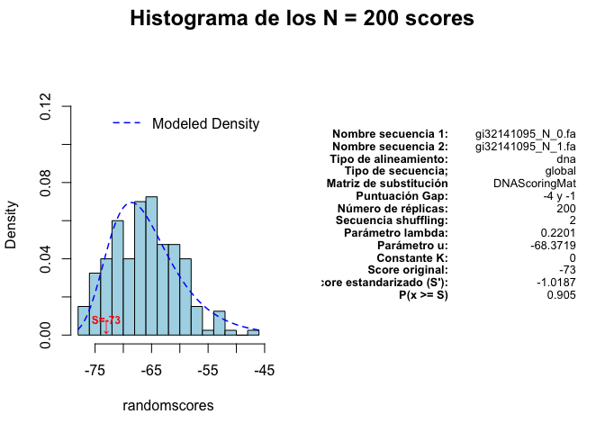

```
## Resumen numérico de las puntuaciones obtenidas al hacer shuffling:
## ==================================================================
##    Min. 1st Qu.  Median    Mean 3rd Qu.    Max.
##  -78.00  -70.00  -66.00  -65.75  -62.00  -46.00
##
##
## Otros resultados numéricos:
## ===========================
##
## lambda      0.22
## u         -68.37
## K           0.00
## S         -73.00
## S'         -1.02
## P(x >= S)   0.90
```

```r
seq_alignment(seq1, seq2, seq_type, seq_align, mat, gap, N, shuff)
```

En este caso, la distribución de las puntuaciones obtenidas al azar sigue una distribución Gumbel($\lambda=0.22$, $u=-68.37$). El *score* original es bajo, -73, apuntando a que las dos secuencias de ADN no están relacionadas. A partir del histograma se puede observar que S se encuentra dentro de la distribución, y además, la probabilidad de que el alineamiento de secuencias al azar tenga una puntuación superior a la putuación de alineación original es muy alta, 0.9, confirmando así que las dos secuencias no tienen relación: al aleatorizar una de las secuencias y calcular la puntuacion del nuevo alineamiento, se obtienen puntuaciones similares a la puntuacion con las secuencias reales.

#### 5.2. Secuencia de proteinas.

Obtendremos dos cadenas de aminoácidos descargándonos los archivos en formato *fasta* desde la página de UniProt, https://www.uniprot.org/. En este ejemplo, se seleccionaran dos proteinas que se sabe que están relacionadas: la Calmodulina-2 (del ratón) y la proteína de unión al calcio 1 (del toro). Los identificadores de estas dos proteinas son P0DP27 y Q9N1R0, respectivamente.

En este caso, se realizará un alineamiento local, se realizará la aleatorización de la primera secuencia 1000 veces y la matrix de puntuaciones a utilizar será la **BLOSUM62**. La penalización por abertura del gap será de -12 y, por extensión, -2.

*Variables de entrada:*

```r
seq1 <- "P0DP27.fa"
seq2 <- "Q9N1R0.fa"
seq_type ="protein"
seq_align = "local"
mat = data("BLOSUM62")
gap = c(-12, -2)
N = 1000
shuff = 1
```

*Llamada a seq_alignment() y resultados:*

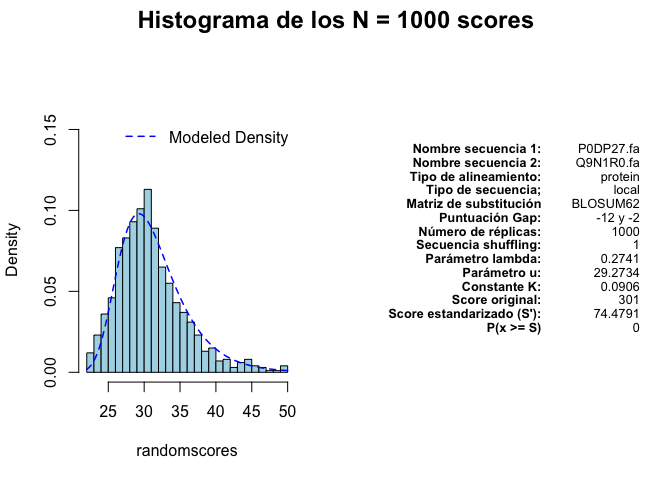

```
## Resumen numérico de las puntuaciones obtenidas al hacer shuffling:
## ==================================================================
##    Min. 1st Qu.  Median    Mean 3rd Qu.    Max.
##   22.00   28.00   31.00   31.38   34.00   50.00
##
##
## Otros resultados numéricos:
## ===========================
##
## lambda      0.27
## u          29.27
## K           0.09
## S         301.00
## S'         74.48
## P(x >= S)   0.00
```

```r
seq_alignment(seq1, seq2, seq_type, seq_align, mat, gap, N, shuff)
```

## Referencias.

- Creación de un paquete: https://support.rstudio.com/hc/en-us/articles/200486488-Developing-Packages-with-RStudio
- Viñetas: http://r-pkgs.had.co.nz/vignettes.html
- Alineamiento de sequencias: https://a-little-book-of-r-for-bioinformatics.readthedocs.io/en/latest/src/chapter4.html
- Significación estadística: documento *Significación_estadistica.pdf* de Atenea.